# An introduction to BNPvegan

Bayesian nonparametric methods for ecology

```r
# If the devtools R package is not already installed
# install.packages("devtools")
devtools::install_github("alessandrozito/BNPvegan")
library(BNPvegan)
```

# Introduction

## Package description

BNPvegan is an R package that implements the fundamental tools of the Bayesian nonparametric literature on Species Sampling models. The package has been designed for ecological applications. In this spirit, we borrowed the name to mimic and extend the existing `vegan` package (Oksanen et al. 2020). In this tutorial we provide both a mathematical overview of the main methods available in the `BNPvegan` package, and we describe in details how to use it an how to interpret its results.

The package is constructed on two building blocks, which are highly interrelated:

- The **Species Sampling model** module -`ssm`- which runs the basic processes in the species sampling model literature (Pitman 1996), including the Dirichlet process (Ferguson 1973) and the Pitman-Yor process (Perman, Pitman, and Yor 1992).
- The **Species Discovery model** module -`sdm`- which runs the species discovery model introduced in (Zito et al. 2020).

Both functions are design to work with a standard `R` sintax, as they accept the classic methods `summary`, `predict`, `coef` and `logLik`. Before dealing with the specifics of each block, we first describe the sample-based methods available in `BNPvegan`.

In both cases, the main input of the package is a vector of `frequencies` representing the species counts observed in a sample. The package is endowed with two example datasets:

1. `Lepidoptera`, which the dataset of butterfly counts in (Fisher, Corbet, and Williams 1943)
2. `fungalOTU`, which contains the counts for some fungal species recorded in a field experiment.

We will use both to show the basic functioning of `ssm` and `sdm`. As a preliminary step however, we demonstrate how to obtain some simple **sample-based quantities**.

# Sample-based quantities

We hereby refer to **sample-based quantities** as those quantities which are not inherited from the the `ssm` or the `sdm` method, but can be directly derived from the vector of species `frequencies` without a specific model fit. These methods are the sample `coverage`, the `Gini` heterogeneity index and the `rarefaction` curve.

From a mathematical perspective, let $X_1, \ldots, X_n$ be a collection of “species” tags, with $X_i$ being the $i$th species observed in the sample. We call *abundance* the total number of species observed, $n$, and *richness* the number distinct species observed in the sample, $K$. Furthermore, let $n_1, \ldots, n_K$ the frequencies with which each species appears in the sample. The three *sample-based* methods offer a way to quickly summaries the feature of the samples based on these simple quantities.

## The sample `coverage`

The **sample coverage** is the sum of the proportions of species that have been observed in the sample. Is is defined as
$$C_n = \sum_{h \in \mathcal{H}} f_h, \quad \mathcal{H} = \{\text{Inexes of the species observed among the } n \text{ data}\}$$
where $\sum_{h=1}^H f_h = 1$ are the *species proportions* and $H$ is the total number of species in the population. Clearly, $K \leq H$, ie. the number of species discovered is less than the true number. The `BNPvegan` package offers a very simple first “estimator” for $C_n$, the old-timely Turing estimator (Good 1953):
$$\hat{C}_n = 1 - \frac{m_1}{n}.$$
with $m_1$ being the number of species observed only once. This estimator can be called in `R` with the function `coverage` as follows.

```r
frequencies <- as.numeric(Lepidoptera)
coverage(frequencies)
```

```
## [1] 0.9975295
```

A first analysis then tells that roughly 99.75% of the species in the population from which `Lepidoptera` was drawn have been discovered.

## The `Gini` heterogeneity index

The **Gini heterogeneity index** is a measure to quantify the amount of **biodiverity** present in the sample. In probabilistic terms, Gini index is the *probability that two species are different when taken at random from the population*:

$$G = 1- \sum_{h = 1}^H f_h^2$$
An estimator for $G$ is
$$\hat{G} = 1 - \frac{1}{n^2}\sum_{j = 1}^K n_j^2,$$
and can be obtained by running the `Gini` command:

```r
Gini(frequencies)
```

```
## [1] 0.9749111
```

## The `rarefaction` method

While often ecologists deal with species frequencies, sometimes the species tags $X_1, \ldots, X_n$, are observed sequentially. This allows to construct an **accumulation curve**, which plots the number of distinct species observed, $K_n$, as a function of the abundance, $n$. However, in the cases in which the data are not sequential, it is necessary to construct the so-called **rarefaction curve**, ie. the *average accumulation curve*. This quantity is derived from a combinatorial argument and it is equal to
$$\bar{K}_i = K - \binom{n}{i}^{-1} \sum_{j = 1}^K \binom{n - n_j}{i}.$$
The `rarefaction` function computes precisely this quantity. Notice that the function can be computationally demanding for large $n$ and large $K$. Thus, a `verbose` option is available if one wants to monitor the process.

```r
# Compute and plot the sample-based rarefaction curve
rar <- rarefaction(frequencies, verbose = TRUE)
```

```
## Number of samples processed: 1254 [10%]
## Number of samples processed: 2508 [20%]
## Number of samples processed: 3762 [30%]
## Number of samples processed: 5016 [40%]
## Number of samples processed: 6270 [50%]
## Number of samples processed: 7524 [60%]
## Number of samples processed: 8778 [70%]
## Number of samples processed: 10032 [80%]
## Number of samples processed: 11286 [90%]
## Number of samples processed: 12540 [100%]
```

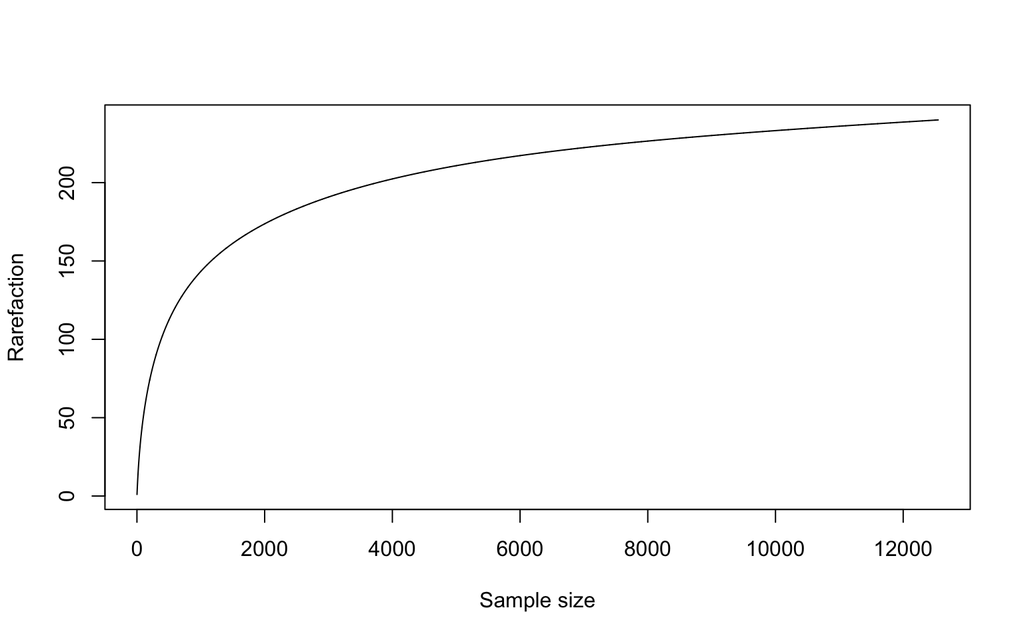

```r
plot(rar, type = "l", xlab = "Sample size", ylab = "Rarefaction")
```

**Note:** the `rarefaction` method performs the same task as the `rarefy` function in the `vegan` package. In the next sections, we show how the same methods are also available for the object of the class `ssm` and `sdm`.

# Species Sampling models

## Sequential allocation scheme

Species sampling models (Pitman 1996) are a class of **generative models** for species distributions which belong to the Bayesian nonprametric literature. The most common species sampling models are the Dirichlet process, `"DP"` (Ferguson 1973) and the Pitman-Yor process, `"PY"` (Perman, Pitman, and Yor 1992). For the purpose of this guide, we will limit our discussion on how species sampling model works to the basics. For an extensive overview on how they work, see De Blasi et al. (2015).

Both the Dirichlet and the Pitman-Yor process generate a species distribution through a sequential prediction scheme. Let $X_{1}, \ldots, X_{n}$ be a sequence of individuals observed, $K_n$ the total number of distinct species observed and $X_{1}^*, \ldots, X_{K_n}^*$ the distinct species labels. In other words, $X_{j}^*$ is the $j$th species label observed in among the first $n$ observations. Then, the species of $X_{n+1}$ is determined by the following prediction rules:

- In the **Dirichlet process**:
  $$X_{n+1} \mid X_1, \ldots, X_n \sim \frac{\alpha}{\alpha + n}(\text{"new species"}) + \sum_{j=1}^{K_n} \frac{n_j}{\alpha + n}\delta_{X_j^*}$$
  with $\alpha >0$;
- In the **Pitman-Yor process**:
  $$X_{n+1} \mid X_1, \ldots, X_n \sim \frac{\alpha - \sigma K_{n}}{\alpha + n}(\text{"new species"}) + \sum_{j=1}^{K_n} \frac{n_j - \sigma}{\alpha + n}\delta_{X_j^*}$$
  with $\alpha >-\sigma$ and $\sigma \in [0, 1)$.

The parameters `alpha` and `sigma` govern the allocation scheme. In particular, it is easy to see that the Pitman-Yor process degenerates to the Dirichlet process when $\sigma = 0$. The interpretation of both equations is rather simple: the species observed at time $n+1$ can either be of a new type or of a previously observed one. In particular, the probability of observing an “old” species is increasing in the number of times that species has been observed in the past. The package `BNPvegan` contains a random sampler for both processes.

```r
set.seed(1)
n <- 1000
# Random sample from a Dirichlet process
rDP(n, alpha = 1)
```

```
## [1] 583 305  75   7   4  16   8   1   1
```

```r
# Random sample from a Pitman-Yor process
rPY(n, alpha = 1, sigma = 0.3)
```

```
##  [1] 180 141 542  43  10  31   1   4   1   3   8   5   1   2  11   2   1   1   3
## [20]   3   1   2   1   1   1   1
```

In the following subsection, we show how to perform inference on the parameters $\alpha$ and $\sigma$ via the `ssm` module.

## The `ssm` module

In what follows, we describe the functioning of the `ssm` module by estimating a Pitman-Yor on the `Lepidoptera` dataset. All the functions are equivalent for the Dirichlet process.

The likelihood function of the Pitman-Yor process is given by the following quantity (known as exchangeable partition probability function).
$$\mathcal{L}(\alpha, \sigma \mid X_1, \ldots, X_n) = \frac{\prod_{j=1}^{K_n-1}(\alpha + j\sigma)}{(\alpha + 1)_{n-1}}\prod_{j=1}^{K_n}(1-\sigma)_{n_j - 1}$$
To estimate the parameters $\alpha$ and $\sigma$, the `ssm` function adopts an empirical Bayes procedure and performs a simple off-theshelf numerical optimization of $\mathcal{L}(\alpha, \sigma \mid X_1, \ldots, X_n)$ via `nlminb`. The commands are the following.

```r
frequencies <- Lepidoptera
fit <- ssm(frequencies, model = "PY")  # set model = "DP" for the Diririchlet process.
summary(fit)  # Summarize the output.
```

```
## Model:
##   Pitman-Yor process
##
## Quantities:
##   Abundance: 12548
##   Richness: 240
##   Estimated sample coverage: 0.9967
##   Expected species after additional 12548 samples: 269
##   New expected species after additional 12548 samples: 29
##   Posterior Gini diversity: 0.975
##
## Parameters:
##       alpha   sigma      loglik
##   ---------  ------  ----------
##    41.99455       0   -53278.74
```

The `summary` function applied to an object of class `ssm` returns the following quantities:

1. `Abundance`: the number of observation in the sample.
2. `Richness`: the number of distinct species in the sample
3. `Estimated sample coverage`: model-based sample coverage
4. `Expected species after additional xx samples`: model-based extrapolation
5. `New expected species after additional xxx samples:`: the difference between `Expected species after additional xx samples` and `Richness`
6. `Posterior Gini diversity`: model-based Gini diversity
7. `Parameters` the empirical Bayes estimates for the parameters of the model.

Notice that in this particular case, $\sigma$ is estimated to be 0 (ie. the Pitman-Yor degenerates to the Dirichlet process). To assess the goodness-of-fit of the `ssm` function, we plot the observed frequency-of-frequencies against the model-based ones.

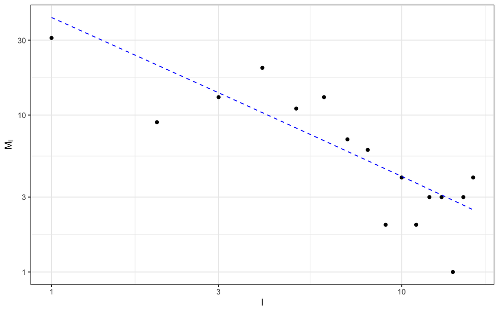

```r
# Frequency-of-frequencies plot
plot(fit, type = "freq")
```

The `ssm` module offers an alternative to the sample-based estimators described in the previous section. In particular, it is endowed with a **model-based** `coverage`, `Gini` diversity and `rarefaction` function. Moreover, due to the sequential urn scheme characteristic, it also allows to **extrapolate** the rarefaction curve via the command `extrapolation`, ie. predict the additional number of distinct species if additional samples where observed. Let’s see the one by one.

### Model-based `coverage`

In a Pitman-Yor model, the distribution of the sample coverage is
$$C_n \mid X_1, \ldots, X_n \sim Beta(n-\sigma K_n, \alpha + \sigma K_n)$$
and the posterior mean is
$$\mathbb{E}(C_n \mid X_1, \ldots, X_n) = \mathbb{P}(X_{n+1} = \text{old species} \mid X_1, \ldots, X_n) = \frac{n-\sigma K_n}{\alpha + n}$$
The advantage of this result is that it allows to obtain **uncertainty quantification on the coverage**. To see this, just run the following commands:

```r
# Estimate for the mean coverage under a Pitman-Yor model
coverage(fit)
```

```
## [1] 0.9966645
```

```r
# Draw random samples from the posterior distribution of the coverage
coverage_samples <- rcoverage(fit)
head(coverage_samples)
```

```
## [1] 0.9970554 0.9959044 0.9971507 0.9965390 0.9966237 0.9975949
```

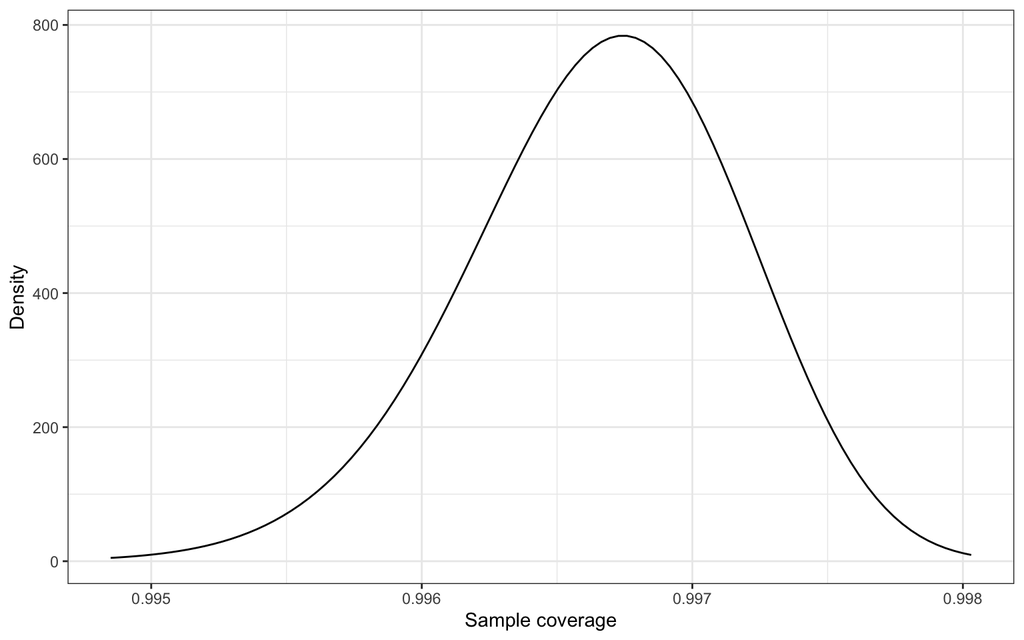

```r
# Plot the posterior distribution of the coverage
plot(fit, type = "coverage")
```

Notice that the `plot` method can be applied to an object of class `ssm`.

### Posterior `Gini` index

The Pitman-Yor process admits a closed for estimator for the Gini index. In particular, the **a priori** Bayesian estimate for the Gini index is
$$\mathbb{E}(G) = \frac{\alpha + \sigma}{\alpha + 1},$$
while the **a posteriori** estimate is
$$\mathbb{E}(G\mid X_1\ldots, X_n) = 1- \frac{1}{(\alpha + n)_2}\Big\{(1 -\sigma)(\alpha + K_n\sigma) + \sum_{j=1}^K(n_j - \sigma)_2\Big\}$$
where $(a)_n = \Gamma(a + n)/\Gamma(a)$ is the Pochhammer symbol. To obtain the estimate for the posteriro Gini index, run the `Gini` function.

```r
Gini(fit)
```

```
## [1] 0.9750008
```

### Model-based `rarefaction` and `extrapolation`.

Both the Dirichlet and the Pitman-Yor process assume that the observations $X_1, \ldots, X_n$ are exchangeable. In other words, the order in which they appear does not matter. Moreover, we can show that the rarefaction curve in the Pitman-Yor process is a Markov process such that $K_1 = 1$ and
$$K_{n+1} \mid K_n = K_{n-1} + D_n, \quad (D_n \mid K_n)\sim Bernoulli\Big(\frac{\alpha + \sigma K_n}{\alpha + n}\Big)$$
Moreover, the associated Bayesian estimate for the rarefaction curve is
$$\mathbb{E}(K_n) = \frac{\alpha}{\sigma}\Big\{ \frac{(\alpha + \sigma)_n}{(\alpha)_n} - 1\Big\}$$
To obtain such a curve and plot ir. just run

```r
# Obtain the rarefaction curve
rar <- rarefaction(fit)
head(rar)
```

```
## [1] 1.000000 1.976741 2.931281 3.864606 4.777640 5.671244
```

```r
tail(rar)
```

```
## [1] 239.9835 239.9869 239.9902 239.9935 239.9969 240.0002
```

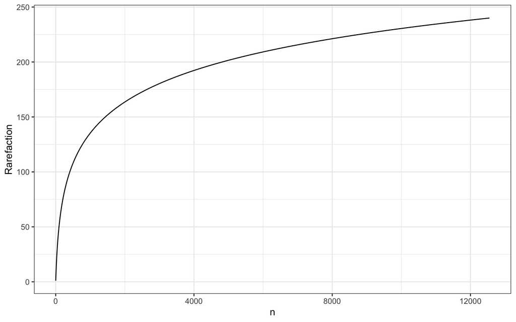

```r
# Plot the rarefaction curve
plot(fit, type = "rarefaction")
```

An additional convenient feature of the Pitman-Yor process is the fact that the prediction of additional number of distinct species if further samples where observed is also available in closed form. In particular, following Favaro et al. (2009), we have that
$$\mathbb{E}(K_m^{(n)} \mid K_n = k) = \Big(k + \frac{\alpha}{\sigma}\Big)\Big\{\frac{(\alpha + n + \sigma)_m}{(\alpha + n)_m} - 1\Big\}$$
Such a quantity can be obtained by specifying the parameter $m$ in the `extrapolation` function. In particular:

```r
# Obtain te extrapolation estimates for m additonal samples
extr <- extrapolation(fit, m = c(1:1000))
head(extr)
```

```
## [1] 240.0033 240.0067 240.0100 240.0133 240.0167 240.0200
```

```r
tail(extr)
```

```
## [1] 243.1944 243.1975 243.2006 243.2036 243.2067 243.2098
```

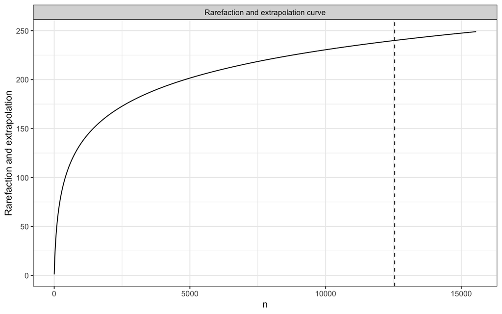

```r
# Plot the extrapolation curve
plot(fit, type = "extrapolation", m = 3000)
```

**A final note**: in the Pitman-Yor process, the growth rate of the number of clusters $K_n$ is $\mathcal{O}(n^\sigma)$, while in the Dirichlet process it is $\mathcal{O}(\alpha \log n)$. In other words, **both models assume an infinite number of species asymptotically**. Thus, they cannot be used to assess the sample saturation. Dealing with converging accumulation curves is the purpose of the `sdm` module.

# Species Discovery models

## Background

- Species discovery models focus directly on the discovery of new species. Unlike Species Sampling models, they are *not* a generative model for a species distribution.
- Species discovery models are designed to fit and predict any accumulation curve, potentially assessing its saturation level, ie. how close the curve is to convergence.
- Their formualtion involves a **direct** modelling of the accumulation curve obtained from the sample.

Let $(D_n)_{n \geq 1}$ be a sequence of *discovery indicators*, such that

$$D_n = \begin{cases}
1 & \text{if} \quad X_n = ``\text{new"}\\
0 & \text{if} \quad X_n = ``\text{observed"}
\end{cases}$$
and trivially $D_n = 1$. Then, an accumulation curve $(K_n)_{n \geq 1}$ is defined as
$$K_n = \sum_{i = 1}^{n} D_i, \quad n \geq 1.$$

The goal of a Species Discovery model is threefold:

1. **Rarefy**: obtain an in-sample estimator for the number of in-sample discoveries $\mathbb{E}(K_n)$. This is called model-based rarefaction, as it estimates a functional form for the rarefaction curve.
2. **Extrapolate**: predict the extected additional number of new species to be observed if more samples where obtained, $\mathbb{E}(K_{n+m} \mid K_n = k)$ and $m \geq 1$.
3. **Saturate**: Estimate the *sample richness* $\mathbb{E}(K_\infty\mid K_n = k)$ and the sample *saturation* $\mathbb{E}(S_n\mid K_n = k)$, with $S_n = K_n/K_\infty$.

All three goals are obtain by directly modelling the discovery probabilities linked to $D_1, \ldots, D_n$. In particular, we let $D_n \stackrel{iid}{\sim} Bernoulli(\pi_n)$, with

$$\pi_{n+1} = \mathbb{P}(D_{n+1} = 1) = \mathcal{S}(n;\theta), \quad \theta \in \Theta \subset \mathbb{R}^p$$
be the discovery probability and $\mathcal{S}(n;\theta)$ a survival function such that

- $S(0; \theta) = 1$ - the first observation is necessarily a new discovery,
- $S(n; \theta) > S(n+1; \theta)$ - the discovery probabilities descrease over time,
- $\lim_{n\to \infty}S(n;\theta) = 0$ - eventually, all species in the sample are discovered.

Then, any functional form that supports the three assumptions can work as a Species discovery model. The package `BNPvegan` supports two type of kernel function:

- The three-parameter log-logistic model, `LL3` (the *deault*):
  $$\mathbb{P}(D_{n+1} = 1) = \frac{\alpha\phi^n}{\alpha\phi^n + n^{1-\sigma} }$$
  with $\alpha >0$, $\sigma <1$ and $\phi \in (0,1)$. Notice that for $\phi = 1$ and $\sigma = 0$, `LL3` has the same discovery probability of the Dirichlet process .
- The `Weibull` model:
  $$\mathbb{P}(D_{n+1} = 1) = \phi^{n^\lambda}$$
  with $\phi \in (0,1)$, $\lambda > 0$. Under both model, the value for $K_\infty = \lim_{n\to \infty} K_n$ is **guaranteed to converge**. In other words, the species discovery model will always ensure a finite saturation.

## The `sdm` module

The `sdm` module runs the model described above on the sample-based rarefaction curve of the specified vector of `frequencies`. The available choice for `model` are `model = "LL3"` (default) and `model = "Weibull"`. Both models are estimated via empirical Bayes by maximizing the log-likelihood associated to the collection of independent Bernoulli random variables. This quantity is equal to
$$\mathcal{L}(\theta\mid D_1, \ldots, D_n) = \prod_{i = 2}^n \mathcal{S}(i-1;\theta)^{D_n}(1-\mathcal{S}(i-1;\theta))^{1-D_n}$$
where the degenerate case $i= 1$ is trivially excluded. As already mentioned above, it is important to notice that often the sequence of species discovery is not available. In the sample based-methods, this problem is solved by computing the **rarefaction** curve from the vector of given `frequencies`, while in the `ssm` module the **exchangeability** assumption implies that the ordering is irrelevant. In the `sdm` case however, the order of the discoveries does matter. To solve this issue, the module maximizes the following likelihood:
$$\mathcal{L}(\theta\mid \tilde{D}_1, \ldots, \tilde{D}_n) = \prod_{i = 2}^n \mathcal{S}(i-1;\theta)^{\tilde{D}_n}(1-\mathcal{S}(i-1;\theta))^{1-\tilde{D}_n}$$
where $\tilde{D}_i = \hat{K}_{i+1}- \hat{K}_i$ and $\hat{K}_i$ is derived from the average sample-based rarefaction curve. Thus, `sdm` works in three steps

1. Compute the sample-based rarefaction curve $\hat{K}_i$ for $i = 1, \ldots, n$
2. Compute the differences and $\tilde{D}_i = \hat{K}_{i+1}- \hat{K}_i$ with $\tilde{D}_i = 1$
3. Obtain the empirical Bayes estimates for $\theta$ via constrained maximization of the likelihood.

In the case of `model = "LL3`, the maximization of the likelihood can be obtained with a simple constrained logistic regression (package `glmnet`). This is makes the `sdm` function particularly efficient

```r
# Fit the species discovery model.
frequencies <- fungalOTU
# Note: verbose controls the state of the construction of the sample-based rarefaction, which is
#       the most demanding part
fit_sdm <- sdm(frequencies, model = "LL3", verbose = TRUE)
```

```
## Number of samples processed: 2124 [10%]
## Number of samples processed: 4248 [20%]
## Number of samples processed: 6372 [30%]
## Number of samples processed: 8496 [40%]
## Number of samples processed: 10620 [50%]
## Number of samples processed: 12744 [60%]
## Number of samples processed: 14868 [70%]
## Number of samples processed: 16992 [80%]
## Number of samples processed: 19116 [90%]
## Number of samples processed: 21240 [100%]
```

```r
# Summarise the output
summary(fit_sdm)
```

```
## Model:
##   Three-parameter log-logistic (LL3)
##
## Quantities:
##   Abundance: 21243
##   Richness: 563
##   Expected species at infinity: 690
##   Standard deviation at infinity: 26.26
##   Expected new species to discover: 127
##   Sample saturation: 0.8159
##
## Parameters:
##       alpha       sigma         phi      logLik
##   ---------  ----------  ----------  ----------
##    45.51308   0.1225816   0.9999824   -2067.835
```

The quantities reported in the summary are:

1. `Abundance`: the number of observation in the sample.
2. `Richness`: the number of distinct species in the sample
3. `Expected species at infinity`: the asymptotic posterior species richness, ie. $\mathbb{E}(K_\infty\mid K_n = k)$
4. `Standard deviation at infinity`: the asymptotic standard deviation ie. $\{Var(K_\infty\mid K_n = k)\}^{1/2}$
5. `Expected new species to discover`: the difference between `Expected species at infinity` and `Richness`
6. `Sample saturation`: the ratio between `Richness` and `Expected species at infinity`.
7. `Parameters` the empirical Bayes estimates for the parameters of the model.

The parameters are easily extracted with the following commands

```r
# Parameters
coef(fit_sdm)
```

```
##      alpha      sigma        phi
## 45.5130801  0.1225816  0.9999824
```

```r
# Loglikelihood
logLik(fit_sdm)
```

```
## [1] -2067.835
```

## `rarefaction` and `extrapolation`

Once the model is estimated, it is very easy to plot both the in-sample rarefaction and to obtain the out of sample prediction. In particular, the convenient property of the `sdm` model ensure that the `rarefaction` and `extrapolation` estimators are easily derived. Indeed, we can prove that under such a formulation the number of distinct species $K_n$ is distributed as a Poisson-binomial distribution,
$$K_n \sim PB\{1,\mathcal{S}(1, \theta), \ldots,\mathcal{S}(n-1, \theta)\},$$
with mean
$$\mathbb{E}(K_n) = \sum_{i =1}^n \mathcal{S}(i-1, \theta).$$
The above quantity can be obtained by using the `rarefaction` method.

```r
# Extract the model-based rarefaction curve
rar_sdm <- rarefaction(fit_sdm)
head(rar_sdm)
```

```
## [1] 1.000000 1.978500 2.939701 3.885226 4.816189 5.733455
```

```r
tail(rar_sdm)
```

```
## [1] 562.9751 562.9801 562.9851 562.9900 562.9950 563.0000
```

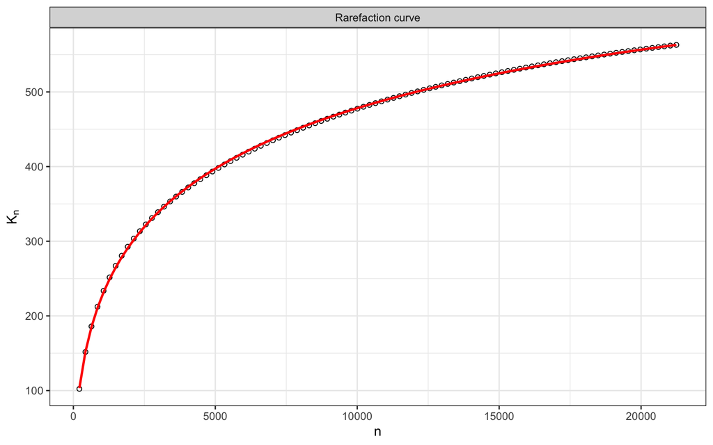

```r
# Plot the model-based and the sample-based rarefaction
plot(fit_sdm, type ="rarefaction")
```

As for extrapolation, it can be easily proved that for any $m\geq 1$,
$$\mathbb{E}(K_{n+m}\mid K_n = k) = k + \sum_{j = 0}^{n-m-1} \mathcal{S}(j, \theta).$$
Again, the method works in the same way as in the `ssm` module

```r
# Extrapolate
extr_sdm <- extrapolation(fit_sdm, m = 1:1000)
head(extr_sdm)
```

```
## [1] 563.0050 563.0100 563.0149 563.0199 563.0249 563.0299
```

```r
tail(extr_sdm)
```

```
## [1] 567.8116 567.8163 567.8210 567.8257 567.8304 567.8351
```

[figure not shown]

```r
# Plot
plot(fit_sdm, type = "extrapolation", m = 10000)
```

```r
# Asymptotic richness estimators
asymptotic_richness(fit_sdm)
```

```
## Exp. species at Inf           sd at Inf          Saturation
##          690.000000           26.261833            0.815942
```

# References

De Blasi, Pierpaolo, Stefano Favaro, Antonio Lijoi, Ramses H. Mena, Igor Prunster, and Matteo Ruggiero. 2015. “Are Gibbs-Type Priors the Most Natural Generalization of the Dirichlet Process?” *IEEE Transactions on Pattern Analysis and Machine Intelligence* 37 (2): 212–29.

Favaro, Stefano, Antonio Lijoi, Ramses H. Mena, and Igor Prunster. 2009. “Bayesian Non-Parametric Inference for Species Variety with a Two-Parameter Poisson–Dirichlet Process Prior.” *Journal of the Royal Statistical Society, Series B* 71: 993–1008.

Ferguson, Thomas S. 1973. “A Bayesian Analysis of Some Nonparametric Problems.” *Annals of Statistics* 1: 209–30.

Fisher, R. A., A. Steven Corbet, and C. B. Williams. 1943. “The Relation Between the Number of Species and the Number of Individuals in a Random Sample of an Animal Population.” *Journal of Animal Ecology* 12 (1): 42–58.

Good, I. J. 1953. “THE Population Frequencies of Species and the Estimation of Population Parameters.” *Biometrika* 40: 237–64.

Oksanen, Jari, F. Guillaume Blanchet, Michael Friendly, Roeland Kindt, Pierre Legendre, Dan McGlinn, Peter R. Minchin, et al. 2020. “Vegan: Community Ecology Package.” 2020.

Perman, Mihael, Jim Pitman, and Marc Yor. 1992. “Size-Biased Sampling of Poisson Point Processes and Excursions.” *Probability Theory and Related Fields* 92 (1): 21–39.

Pitman, Jim. 1996. “Some Developments of the Blackwell-Macqueen Urn Scheme.” In *Statistics, Probability and Game Theory. Papers in Honor of David Blackwell*, edited by T. S. Ferguson, L. S. Shapley, and James B. MacQueen, 30:245–67. IMS Lecture notes, Monograph Series. Hayward: Institute of Mathematical Statistics.

Zito, Alessandro, Tommaso Rigon, Otso Ovaskainen, and D. B. Dunson. 2020. “Bayesian Nonparametric Modelling of Sequential Discoveries.” *Https://Arxiv.org/Abs/2011.06629s*.